# House Price Prediction

Saurav Chetry

January 3, 2020

**Data Selection:**

From Library **mlbench**, I am using **BostonHousing2** dataset, which is a dataframe of 506 observations and 19 attributes. The project will consider **cmedv** variable as the response from its relationships with other predictor variables. The dataset has two categorical variables, viz, **town** and **chas** and would be evaluated for determining the response.

**Analysis:**

**a. Introduction:**

**Statement**: Here, I will make an attempt to analyse the dataset to select a right model for predicting house prices in Boston.

**BostonHousing2** is a database with housing information around Boston city from the 1970 census, and lists down the median house prices in USD 1000’s. The dataframe **BostonHousing2** is the corrected version with additional spatial information and is available at: http://lib.stat.cmu.edu/datasets/

The original data are 506 observations on 14 variables, $cmedv$ being the target variable: The following table summarizes the attributes and their types:

[output not shown]

With regards to predicting the house prices, the attributes that I think would be valuable are: **ptratio, town, rad, dis, rm, nox and crim** and I would use them to fit the best model for this project.

**b. Methods:**

```r
#install.packages("mlbench")
#?BostonHousing2

data("BostonHousing2")
BostonHousing2 = na.omit(BostonHousing2)

#dropping attributes which are highly collinear(mdev) and those with location details(lat,lon,town) and industrial areas(indus)
BostonHousing2 = subset(BostonHousing2, select = -c(medv,tract,lon,lat,indus,town))

#test-train split

split = round(nrow(BostonHousing2) * .80)
bos_trn = BostonHousing2[1:split,]
bos_tst = BostonHousing2[(split + 1):nrow(BostonHousing2),]

#full model and its summary
bm = lm( cmedv ~ ., data = bos_trn)

#filtering on the statistically significant predictors for medv at alpha = 0.01
summary(bm)$coefficients
```

```
##                  Estimate  Std. Error    t value     Pr(>|t|)
## (Intercept)  29.808906211 6.133266581  4.8602006 1.699336e-06
## crim         -0.193469939 0.051212820 -3.7777638 1.828075e-04
## zn            0.043936792 0.014106433  3.1146636 1.976921e-03
## chas1         1.981703770 0.885448706  2.2380786 2.577685e-02
## nox         -13.793047578 4.345162054 -3.1743460 1.620347e-03
## rm            4.732345593 0.480602621  9.8466912 1.377141e-20
## age           0.001920516 0.014342940  0.1338997 8.935506e-01
## dis          -1.351139683 0.207124336 -6.5233265 2.125620e-10
## rad           0.447857750 0.084759443  5.2838685 2.103413e-07
## tax          -0.014814517 0.004245851 -3.4891748 5.395168e-04
## ptratio      -0.778802558 0.138585334 -5.6196607 3.636092e-08
## b            -0.002532068 0.006528362 -0.3878565 6.983327e-01
## lstat        -0.528111442 0.059019961 -8.9480141 1.460223e-17
```

```r
subset(summary(bm)$coefficients,summary(bm)$coefficients[,4] < 0.05)
```

```
##                 Estimate  Std. Error   t value     Pr(>|t|)
## (Intercept)  29.80890621 6.133266581  4.860201 1.699336e-06
## crim         -0.19346994 0.051212820 -3.777764 1.828075e-04
## zn            0.04393679 0.014106433  3.114664 1.976921e-03
## chas1         1.98170377 0.885448706  2.238079 2.577685e-02
## nox         -13.79304758 4.345162054 -3.174346 1.620347e-03
## rm            4.73234559 0.480602621  9.846691 1.377141e-20
## dis          -1.35113968 0.207124336 -6.523327 2.125620e-10
## rad           0.44785775 0.084759443  5.283869 2.103413e-07
## tax          -0.01481452 0.004245851 -3.489175 5.395168e-04
## ptratio      -0.77880256 0.138585334 -5.619661 3.636092e-08
## lstat        -0.52811144 0.059019961 -8.948014 1.460223e-17
```

From the summary of the fitted model, the *age* & *b* attribute does not look good as the **Null Hypothesis of the predictors( in presence with other predictor) of the full model Fails to be Rejected**.

Next, I will fit a model with predictor which I think are statistically significant at $alpha = 0.05$.

```r
model1 = lm(cmedv ~ ptratio + rad + dis + rm + nox + crim + chas + lstat + zn + tax, data = bos_trn)
subset(summary(model1)$coefficients,summary(model1)$coefficients[,4] < 0.05)
```

```
##                Estimate  Std. Error   t value     Pr(>|t|)
## (Intercept)  28.7529158 5.549121405  5.181526 3.521516e-07
## ptratio      -0.7804610 0.137459587 -5.677749 2.652009e-08
## rad           0.4423817 0.083504501  5.297698 1.955204e-07
## dis          -1.3557003 0.197862062 -6.851744 2.820316e-11
## rm            4.7221988 0.462404479 10.212269 7.049849e-22
## nox         -13.2320153 4.047733843 -3.268993 1.174126e-03
## crim         -0.1936400 0.050899070 -3.804392 1.647268e-04
## chas1         1.9931510 0.882624546  2.258209 2.447900e-02
## lstat        -0.5269432 0.054631407 -9.645426 6.643297e-20
## zn            0.0436920 0.013951289  3.131753 1.867381e-03
## tax          -0.0146461 0.004216056 -3.473887 5.699260e-04
```

This model looks to have better predictor set, as all predictor’s **Null Hypothesis is Rejected** Next, I will attempt to find predictors which are significant at $alpha = 0.01$

```r
#finding significant predictors at lower significance levels alpha  = 0.01
subset(summary(model1)$coefficients, summary(model1)$coefficients[,4] < 0.01)
```

```
##                Estimate  Std. Error   t value     Pr(>|t|)
## (Intercept)  28.7529158 5.549121405  5.181526 3.521516e-07
## ptratio      -0.7804610 0.137459587 -5.677749 2.652009e-08
## rad           0.4423817 0.083504501  5.297698 1.955204e-07
## dis          -1.3557003 0.197862062 -6.851744 2.820316e-11
## rm            4.7221988 0.462404479 10.212269 7.049849e-22
## nox         -13.2320153 4.047733843 -3.268993 1.174126e-03
## crim         -0.1936400 0.050899070 -3.804392 1.647268e-04
## lstat        -0.5269432 0.054631407 -9.645426 6.643297e-20
## zn            0.0436920 0.013951289  3.131753 1.867381e-03
## tax          -0.0146461 0.004216056 -3.473887 5.699260e-04
```

```r
#fitting the significant predictors( chas turns out to be not significant)
model2 = lm(cmedv ~ ptratio + rad + dis + rm + nox + crim + lstat + zn + tax, data = bos_trn)
summary(model2)$r.squared
```

```
## [1] 0.7343554
```

From the above test, I will choose to use the model2 for further analysis and verification.

**Verification of model2**

```r
#AIC test
model_selected_aic = step(bm, direction = "backward", trace = 0)
names(coef(model_selected_aic))
```

```
##  [1] "(Intercept)" "crim"        "zn"          "chas1"       "nox"
##  [6] "rm"          "dis"         "rad"         "tax"         "ptratio"
## [11] "lstat"
```

```r
summary(model_selected_aic)$r.squared
```

```
## [1] 0.7377497
```

```r
#AIC test 2 with two way interactions
model_start = lm(cmedv ~ (.)^2, data = bos_trn)
model_selected_aic_int = step(model_start, direction = "backward", trace = 0)
names(coef(model_selected_aic_int))
```

```
##  [1] "(Intercept)"   "crim"          "zn"            "chas1"
##  [5] "nox"           "rm"            "age"           "dis"
##  [9] "rad"           "tax"           "ptratio"       "b"
## [13] "lstat"         "crim:chas1"    "crim:nox"      "crim:age"
## [17] "crim:dis"      "crim:rad"      "crim:tax"      "crim:lstat"
## [21] "zn:chas1"      "zn:dis"        "zn:rad"        "zn:tax"
## [25] "zn:b"          "zn:lstat"      "chas1:nox"     "chas1:rm"
## [29] "chas1:dis"     "chas1:rad"     "chas1:tax"     "chas1:ptratio"
## [33] "chas1:b"       "nox:age"       "nox:rad"       "nox:tax"
## [37] "nox:ptratio"   "nox:b"         "nox:lstat"     "rm:age"
## [41] "rm:rad"        "rm:tax"        "rm:ptratio"    "rm:b"
## [45] "rm:lstat"      "age:dis"       "age:rad"       "age:b"
## [49] "age:lstat"     "dis:rad"       "dis:lstat"     "rad:tax"
## [53] "rad:ptratio"   "rad:b"         "rad:lstat"     "tax:ptratio"
## [57] "tax:lstat"     "ptratio:lstat"
```

```r
summary(model_selected_aic_int)$r.squared
```

```
## [1] 0.9381225
```

Comparing the AIC selected model with full model and model2

```r
#comparing model2 with full model
anova(model2, bm)[2,"Pr(>F)"]
```

```
## [1] 0.1566313
```

As $p-value$ is big, preferred model is model2

```r
#comparing model2, selected model from AIC and selected model from AIC with interactions.
anova(model_selected_aic,model2)[2,"Pr(>F)"]
```

```
## [1] 0.024479
```

```r
anova(model_selected_aic, model_selected_aic_int)[2,"Pr(>F)"]
```

```
## [1] 7.259136e-83
```

Based on the Anova tests, the preferred model is still the **model_selected_aic_int** which also has the highest $r.squared$ value.

**Further Analysis of the preferred model**

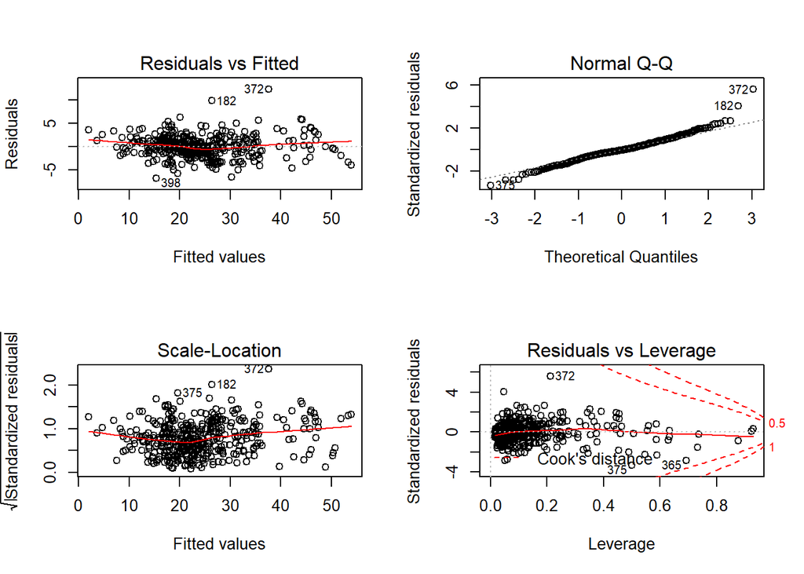

```r
par(mfrow = c(2,2))
plot(model_selected_aic_int)
```

```r
sqrt(mean(resid(model_selected_aic_int) ^ 2))
```

```
## [1] 2.303212
```

**Checking the assumptions for constant variance and normal distribution** From the Fitted vs Residual plot and Q-Q plot, there appears some violation of assumptions. I will perform the Breusch-Pagan Test and Shapiro-Wilk test for further checks.

```r
bptest(model_selected_aic_int)
```

```
##
##  studentized Breusch-Pagan test
##
## data:  model_selected_aic_int
## BP = 114.1, df = 57, p-value = 1.086e-05
```

For BP test on *model_selected_aic_int*, we see a small p-value, so we reject the null of homoscedasticity. The constant variance assumption is violated. This matches our findings with a fitted versus residuals plot.

```r
shapiro.test(resid(model_selected_aic_int))
```

```
##
##  Shapiro-Wilk normality test
##
## data:  resid(model_selected_aic_int)
## W = 0.97363, p-value = 1.037e-06
```

From the Shapiro-Wilk test for model_selected_aic2, a small $p-value$ indicates there is only a small probability the data could have been sampled from a normal distribution.

**From model diagnostics, it is confirmed that model_selected_aic_int needs further analysis and modifications like response and predictor transformations, predictor interactions and polynomial terms. Besides these, I will also test the effect of outliers, leverage and influential points and cleanse the dataset accordingly**

```r
#finding outliers and influential points

sum(hatvalues(model_selected_aic_int) > 2 * mean(hatvalues(model_selected_aic_int)))
```

```
## [1] 45
```

```r
sum(abs(rstandard(model_selected_aic_int)) > 2, na.rm = TRUE)
```

```
## [1] 20
```

```r
inf_points = cooks.distance(model_selected_aic_int)
sum(inf_points > 4 / length(inf_points), na.rm = TRUE)
```

```
## [1] 40
```

```r
rem_points = inf_points > 4 / length(inf_points)
```

model_selected_aic_int has 45 points of high leverage and 20 point with large residual. Among these 40 points are influential from Cooks Distance calculation.

```r
#removing influential points to check model assumptions
model_aic_int_fix = lm(model_selected_aic_int, subset = inf_points <= 4 / length(inf_points))
```

Lets verify the plots and diagnostic tests again on *model_aic_int_fix*

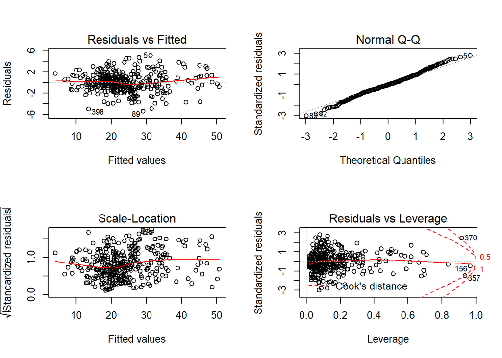

```r
par(mfrow = c(2,2))
plot(model_aic_int_fix)
```

```r
bptest(model_aic_int_fix)
```

```
##
##  studentized Breusch-Pagan test
##
## data:  model_aic_int_fix
## BP = 80.099, df = 57, p-value = 0.02352
```

```r
shapiro.test(resid(model_aic_int_fix))
```

```
##
##  Shapiro-Wilk normality test
##
## data:  resid(model_aic_int_fix)
## W = 0.99107, p-value = 0.02643
```

```r
summary(model_aic_int_fix)$r.squared
```

```
## [1] 0.9567399
```

As I intend to have a prediction model, lets compare the models so far with respect to train RMSE, test RMSE and LOOCV-RMSE.

```r
#rmse definition
rmse = function(actual, predicted) {
  sqrt(mean((actual - predicted) ^ 2))
}
```

```r
# RMSE Calculations
result = data.frame('Model' = c('model2', 'model_selected_aic', 'model_selected_aic_int', 'model_aic_int_fix'),
                    'Train RMSE' = c(rmse(bos_trn$cmedv, predict(model2)), rmse(bos_trn$cmedv, predict(model_selected_aic)), rmse(bos_trn$cmedv, predict(model_selected_aic_int)),rmse(bos_trn$cmedv, predict(model_aic_int_fix))),
                    'Test RMSE' = c(rmse(bos_tst$cmedv, predict(model2, bos_tst)), rmse(bos_tst$cmedv, predict(model_selected_aic, bos_tst)), rmse(bos_tst$cmedv, predict(model_selected_aic_int, bos_tst)),  rmse(bos_tst$cmedv, predict(model_aic_int_fix, bos_tst))))


result %>%
  kable(digits = 2) %>%
  kable_styling()
```

| Model | Train.RMSE | Test.RMSE |
| --- | --- | --- |
| model2 | 4.77 | 5.69 |
| model_selected_aic | 4.74 | 5.45 |
| model_selected_aic_int | 2.30 | 14.74 |
| model_aic_int_fix | 9.69 | 15.15 |

```r
#LOOCV-RMSE

calc_loocv_rmse = function(model) {
  sqrt(mean((resid(model) / (1 - hatvalues(model))) ^ 2))
}
calc_loocv_rmse(model2)
```

```
## [1] 4.964532
```

```r
calc_loocv_rmse(model_selected_aic)
```

```
## [1] 4.960245
```

```r
calc_loocv_rmse(model_selected_aic_int)
```

```
## [1] 2.942174
```

```r
calc_loocv_rmse(model_aic_int_fix)
```

```
## [1] 2.296457
```

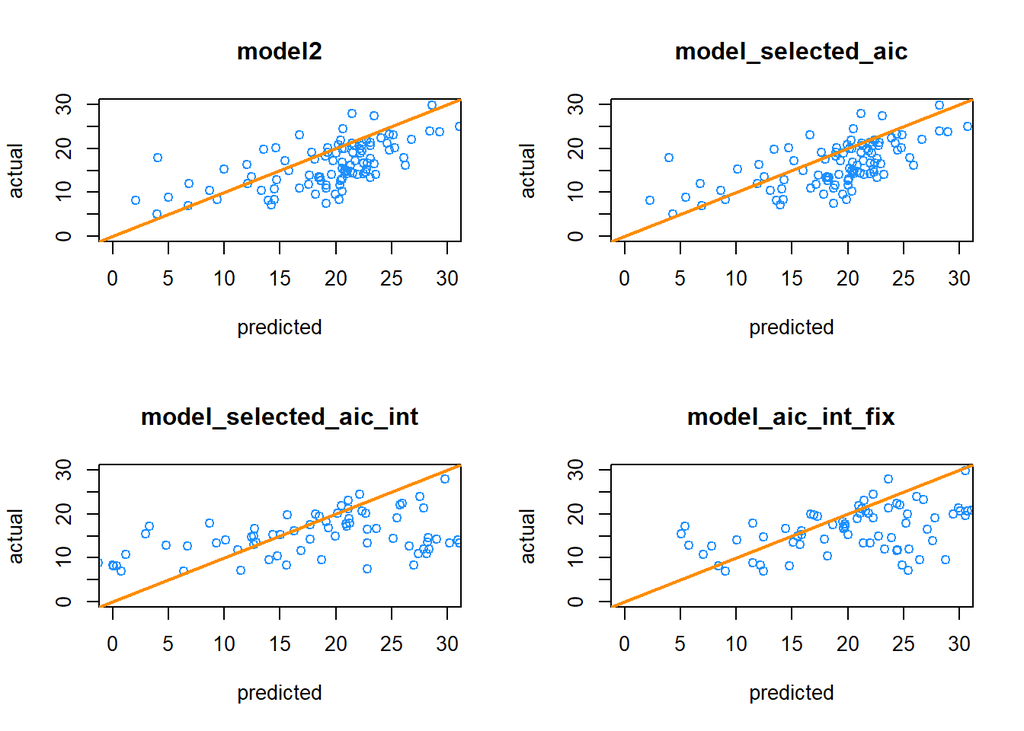

```r
#actual vs predicted

par(mfrow = c(2,2))

plot(predict(model2, bos_tst),bos_tst$cmedv, xlab="predicted",ylab="actual",
     xlim = c( 0, 30), ylim = c(0, 30), col = "dodgerblue", main = "model2")
abline(a=0,b=1, col = "darkorange", lwd = 2)

plot(predict(model_selected_aic, bos_tst),bos_tst$cmedv, xlab="predicted",ylab="actual",
     xlim = c( 0, 30), ylim = c(0, 30), col = "dodgerblue", main = "model_selected_aic")
abline(a=0,b=1, col = "darkorange", lwd = 2)

plot(predict(model_selected_aic_int, bos_tst),bos_tst$cmedv, xlab="predicted",ylab="actual",
     xlim = c( 0, 30), ylim = c(0, 30), col = "dodgerblue", main = "model_selected_aic_int")
abline(a=0,b=1, col = "darkorange", lwd = 2)

plot(predict(model_aic_int_fix, bos_tst),bos_tst$cmedv, xlab="predicted",ylab="actual",
     xlim = c( 0, 30), ylim = c(0, 30), col = "dodgerblue", main = "model_aic_int_fix")
abline(a=0,b=1, col = "darkorange", lwd = 2)
```

From the RMSE, LOOCV-RMSE and actual predicted plots, none of the models seems to be performing a better prediction. Majority of the predicted median house prices are higher than the actual prices.

As next steps, I will check for transformations of the predictor and response and check for lowest RMSE values.

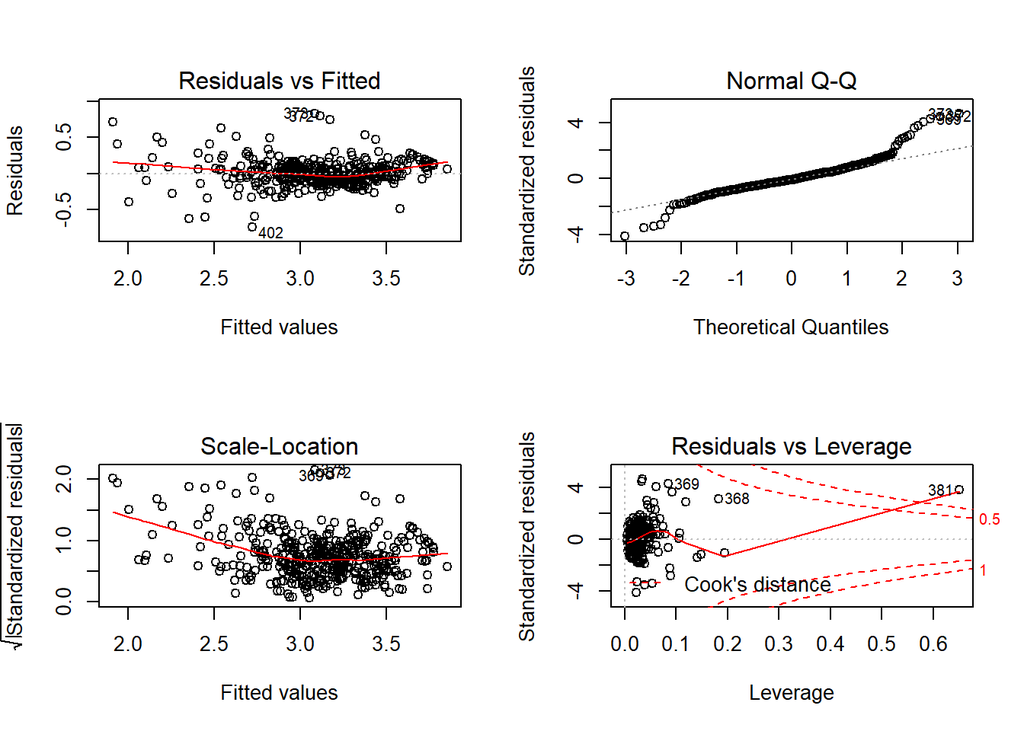

```r
#response transformation for assumably significant variables.

model_res_trans = lm(log(cmedv) ~ ptratio + rm + crim + nox + b + lstat + age + dis + rad + tax, data = bos_trn)

par(mfrow = c(2,2))
plot(model_res_trans)
```

```r
bptest(model_res_trans)
```

```
##
##  studentized Breusch-Pagan test
##
## data:  model_res_trans
## BP = 112.26, df = 10, p-value < 2.2e-16
```

```r
shapiro.test(resid(model_res_trans))
```

```
##
##  Shapiro-Wilk normality test
##
## data:  resid(model_res_trans)
## W = 0.92491, p-value = 2.283e-13
```

The response transformation, does not have a conforming model assumptions.

```r
#finding outliers and influential points

sum(hatvalues(model_res_trans) > 2 * mean(hatvalues(model_res_trans)))
```

```
## [1] 29
```

```r
sum(abs(rstandard(model_res_trans)) > 2, na.rm = TRUE)
```

```
## [1] 19
```

```r
inf_points2 = cooks.distance(model_res_trans)
sum(inf_points2 > 4 / length(inf_points2), na.rm = TRUE)
```

```
## [1] 27
```

```r
rem_points2 = inf_points2 > 4 / length(inf_points2)
```

model_res_trans has 29 points of high leverage and 19 point with large residual. Among these 27 points are influential from Cooks Distance calculation.

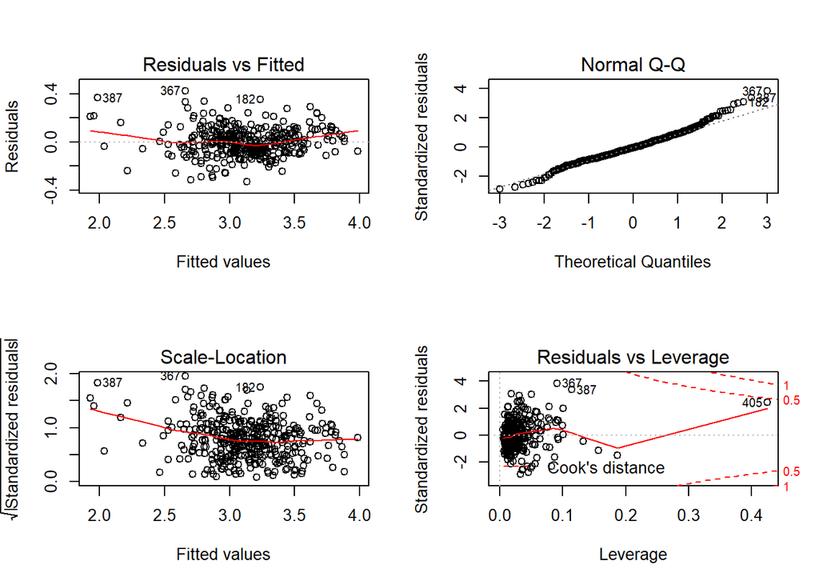

```r
#removing influential points to check model assumptions
model_res_trans_fix = lm(model_res_trans, subset = inf_points2 <= 4 / length(inf_points2))

#checking assumptions
par(mfrow = c(2,2))
plot(model_res_trans_fix)
```

```r
bptest(model_res_trans_fix)
```

```
##
##  studentized Breusch-Pagan test
##
## data:  model_res_trans_fix
## BP = 68.521, df = 10, p-value = 8.55e-11
```

```r
shapiro.test(resid(model_res_trans_fix))
```

```
##
##  Shapiro-Wilk normality test
##
## data:  resid(model_res_trans_fix)
## W = 0.98455, p-value = 0.0004574
```

```r
summary(model_res_trans_fix)$r.squared
```

```
## [1] 0.8873163
```

```r
calc_loocv_rmse(model_res_trans_fix)
```

```
## [1] 0.1205345
```

```r
rmse(bos_trn$cmedv, exp(predict(model_res_trans_fix)))
```

```
## [1] 9.926192
```

```r
rmse(bos_tst$cmedv, exp(predict(model_res_trans_fix, bos_tst)))
```

```
## [1] 3.93472
```

There is an improvement in the normality assumption as well as in test RMSE value.

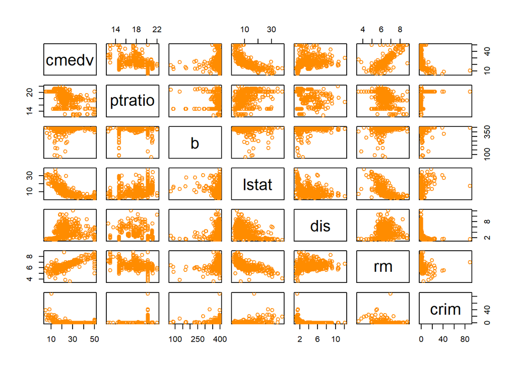

```r
#Predictor transformation

pairs(~ cmedv + ptratio + b + lstat + dis + rm + crim, data = bos_trn, pch = 1, col = "darkorange")
```

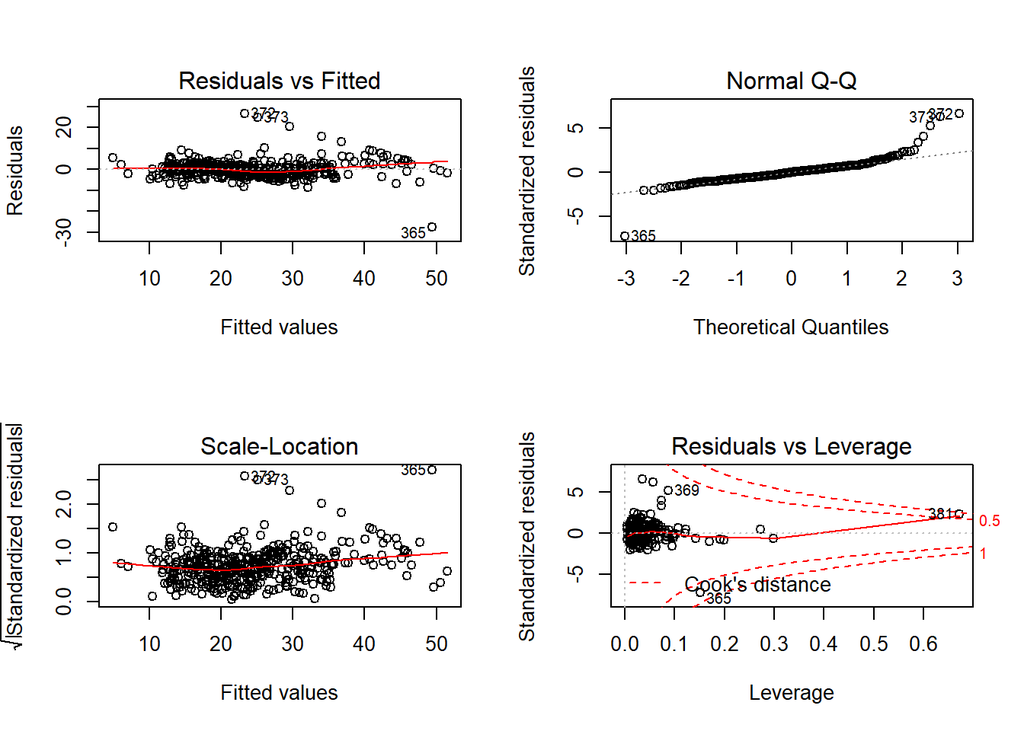

```r
# lstat and rm seem to have linear relationship with cmedv. Adding polynomial terms to check the fitted model.

model_pred_trans = lm(cmedv ~ lstat + crim + rm + dis + b + chas + nox + rad + tax + ptratio + I(lstat^2) + I(rm^2) , data = bos_trn)

par(mfrow = c(2,2))
plot(model_pred_trans)
```

```r
bptest(model_pred_trans)
```

```
##
##  studentized Breusch-Pagan test
##
## data:  model_pred_trans
## BP = 80.095, df = 12, p-value = 3.959e-12
```

```r
shapiro.test(resid(model_pred_trans))
```

```
##
##  Shapiro-Wilk normality test
##
## data:  resid(model_pred_trans)
## W = 0.83699, p-value < 2.2e-16
```

Model assumptions are violated.

```r
#finding outliers and influential points

sum(hatvalues(model_pred_trans) > 2 * mean(hatvalues(model_pred_trans)))
```

```
## [1] 32
```

```r
sum(abs(rstandard(model_pred_trans)) > 2, na.rm = TRUE)
```

```
## [1] 13
```

```r
inf_points3 = cooks.distance(model_pred_trans)
sum(inf_points3 > 4 / length(inf_points3), na.rm = TRUE)
```

```
## [1] 17
```

```r
rem_points3 = inf_points3 > 4 / length(inf_points3)
```

model_pred_trans has 32 points of high leverage and 13 point with large residual. Among these 17 points are influential from Cooks Distance calculation.

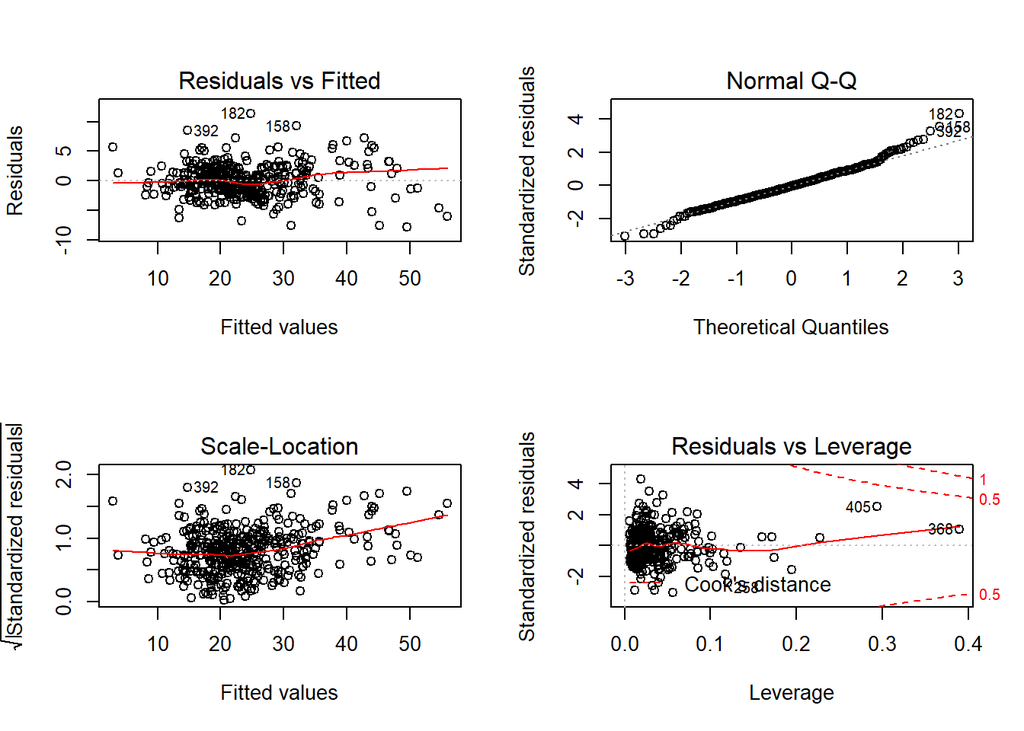

```r
#removing influential points to check model assumptions
model_pred_trans_fix = lm(model_pred_trans, subset = inf_points3 <= 4 / length(inf_points3))

#checking assumptions
par(mfrow = c(2,2))
plot(model_pred_trans_fix)
```

```r
bptest(model_pred_trans_fix)
```

```
##
##  studentized Breusch-Pagan test
##
## data:  model_pred_trans_fix
## BP = 44.4, df = 12, p-value = 1.305e-05
```

```r
shapiro.test(resid(model_pred_trans_fix))
```

```
##
##  Shapiro-Wilk normality test
##
## data:  resid(model_pred_trans_fix)
## W = 0.9834, p-value = 0.000196
```

```r
summary(model_pred_trans_fix)$r.squared
```

```
## [1] 0.9082454
```

```r
calc_loocv_rmse(model_pred_trans_fix)
```

```
## [1] 2.738876
```

```r
rmse(bos_trn$cmedv, predict(model_pred_trans_fix))
```

```
## [1] 9.510312
```

```r
rmse(bos_tst$cmedv, predict(model_pred_trans_fix, bos_tst))
```

```
## [1] 4.049455
```

** Experimenting with both predictor and response transformaion**

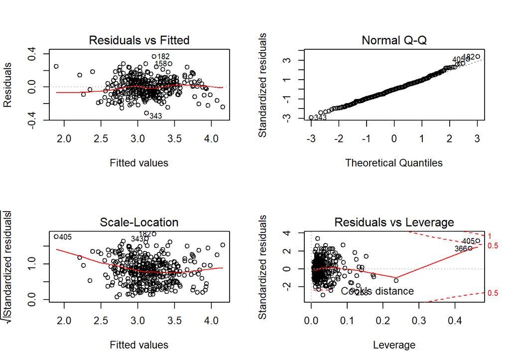

```r
model_mix = lm(log(cmedv) ~ ptratio + rm + crim + nox + b + lstat + age + dis + rad + tax + I(rm ^2) + I(lstat ^2), data = bos_trn)
inf_points4 = cooks.distance(model_mix)
model_mix_fix = lm(model_mix, subset = inf_points4 <= 4 / length(inf_points4) )

par(mfrow = c(2,2))
plot(model_mix_fix)
```

```r
bptest(model_mix_fix)
```

```
##
##  studentized Breusch-Pagan test
##
## data:  model_mix_fix
## BP = 45.423, df = 12, p-value = 8.72e-06
```

```r
shapiro.test(resid(model_mix_fix))
```

```
##
##  Shapiro-Wilk normality test
##
## data:  resid(model_mix_fix)
## W = 0.99614, p-value = 0.4853
```

```r
summary(model_mix_fix)$r.squared
```

```
## [1] 0.8966536
```

```r
calc_loocv_rmse(model_mix_fix)
```

```
## [1] 0.1148345
```

```r
rmse(bos_trn$cmedv, exp(predict(model_mix_fix)))
```

```
## [1] 9.698517
```

```r
rmse(bos_tst$cmedv, exp(predict(model_mix_fix, bos_tst)))
```

```
## [1] 3.570833
```

As I only care about prediction, I don’t need to worry about correlation vs causation, or need to worry about model assumptions, therefore I will directly jump to finding out the best model with lowest RMSE & LOOCV RMSE values found via penalizing the overfitting large models by using one of AIC or BIC methods.

```r
result = data.frame('Model' = c('model2', 'model_selected_aic', 'model_selected_aic_int', 'model_pred_trans', 'model_res_trans', 'model_aic_int_fix', 'model_res_trans_fix', 'model_pred_trans_fix','model_mix_fix'),

                    'Train RMSE' = c(rmse(bos_trn$cmedv, predict(model2)), rmse(bos_trn$cmedv, predict(model_selected_aic)), rmse(bos_trn$cmedv, predict(model_selected_aic_int)),rmse(bos_trn$cmedv, predict(model_pred_trans)),rmse(bos_trn$cmedv, exp(predict(model_res_trans))), rmse(bos_trn$cmedv, predict(model_aic_int_fix)),rmse(bos_trn$cmedv, exp(predict(model_res_trans_fix))), rmse(bos_trn$cmedv, predict(model_pred_trans_fix)),rmse(bos_trn$cmedv, exp(predict(model_mix_fix)))),

                    'Test RMSE' = c(rmse(bos_tst$cmedv, predict(model2, bos_tst)), rmse(bos_tst$cmedv, predict(model_selected_aic, bos_tst)), rmse(bos_tst$cmedv, predict(model_selected_aic_int, bos_tst)), rmse(bos_tst$cmedv, predict(model_pred_trans, bos_tst)),rmse(bos_tst$cmedv, exp(predict(model_res_trans, bos_tst))), rmse(bos_tst$cmedv, predict(model_aic_int_fix, bos_tst)), rmse(bos_tst$cmedv, exp(predict(model_res_trans_fix, bos_tst))), rmse(bos_tst$cmedv, predict(model_pred_trans_fix, bos_tst)),rmse(bos_tst$cmedv, exp(predict(model_mix_fix, bos_tst)))),

                    'LOOCV-RMSE' = c(calc_loocv_rmse(model2),calc_loocv_rmse(model_selected_aic),calc_loocv_rmse(model_selected_aic_int),calc_loocv_rmse(model_pred_trans),calc_loocv_rmse(model_res_trans), calc_loocv_rmse(model_aic_int_fix),calc_loocv_rmse(model_res_trans_fix), calc_loocv_rmse(model_pred_trans_fix),calc_loocv_rmse(model_mix_fix)),

                    "adj.r.squared" = c(summary(model2)$adj.r.squared, summary(model_selected_aic)$adj.r.squared, summary(model_selected_aic_int)$adj.r.squared, summary(model_pred_trans)$adj.r.squared, summary(model_res_trans)$adj.r.squared, summary(model_aic_int_fix)$adj.r.squared, summary(model_res_trans_fix)$adj.r.squared, summary(model_pred_trans_fix)$adj.r.squared, summary(model_mix_fix)$adj.r.squared)

)

kable(result, digits = 2) %>%
  kable_styling("striped", full_width = T) %>%
  column_spec(3:4, bold = T) %>%
  row_spec(9:9, bold = T, color = "white", background = "green")
```

| Model | Train.RMSE | Test.RMSE | LOOCV.RMSE | adj.r.squared |
| --- | --- | --- | --- | --- |
| model2 | 4.77 | 5.69 | 4.96 | 0.73 |
| model_selected_aic | 4.74 | 5.45 | 4.96 | 0.73 |
| model_selected_aic_int | 2.30 | 14.74 | 2.94 | 0.93 |
| model_pred_trans | 4.05 | 3.49 | 4.36 | 0.80 |
| model_res_trans | 4.43 | 3.56 | 0.20 | 0.77 |
| model_aic_int_fix | 9.69 | 15.15 | 2.30 | 0.95 |
| model_res_trans_fix | 9.93 | 3.93 | 0.12 | 0.88 |
| model_pred_trans_fix | 9.51 | 4.05 | 2.74 | 0.91 |
| model_mix_fix | 9.70 | 3.57 | 0.11 | 0.89 |

**c. Results**

From LOOCV-RMSE, the best model seems to be **model_mix_fix**.

Next, I will plot the actual vs predicted median house prices to choose the best model for the predictions.

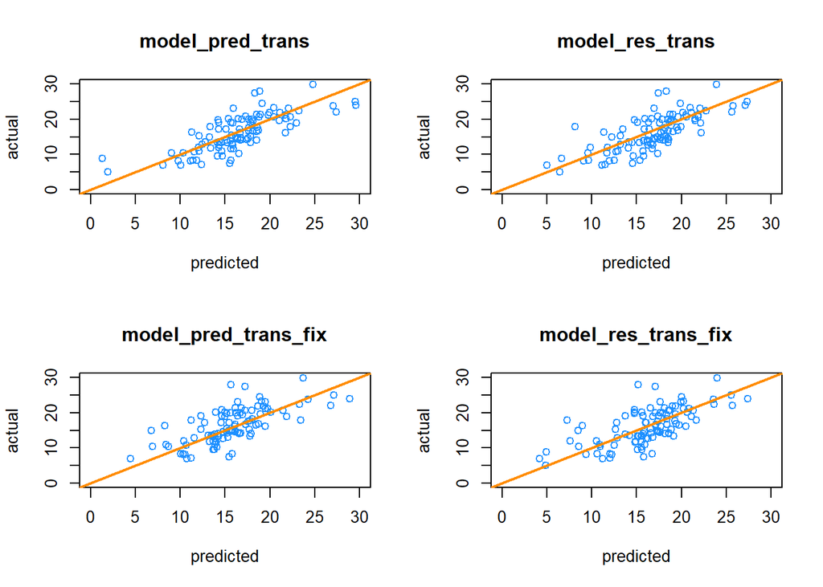

```r
par(mfrow = c(2,2))

plot(predict(model_pred_trans, bos_tst),bos_tst$cmedv, xlab="predicted",ylab="actual",
     xlim = c( 0, 30), ylim = c(0, 30), col = "dodgerblue", main = "model_pred_trans")
abline(a=0,b=1, col = "darkorange", lwd = 2)

plot(exp(predict(model_res_trans, bos_tst)),bos_tst$cmedv, xlab="predicted",ylab="actual",
     xlim = c( 0, 30), ylim = c(0, 30), col = "dodgerblue", main = "model_res_trans")
abline(a=0,b=1, col = "darkorange", lwd = 2)

plot(predict(model_pred_trans_fix, bos_tst),bos_tst$cmedv, xlab="predicted",ylab="actual",
     xlim = c( 0, 30), ylim = c(0, 30), col = "dodgerblue", main = "model_pred_trans_fix")
abline(a=0,b=1, col = "darkorange", lwd = 2)

plot(exp(predict(model_res_trans_fix, bos_tst)),bos_tst$cmedv, xlab="predicted",ylab="actual",
     xlim = c( 0, 30), ylim = c(0, 30), col = "dodgerblue", main = "model_res_trans_fix")
abline(a=0,b=1, col = "darkorange", lwd = 2)
```

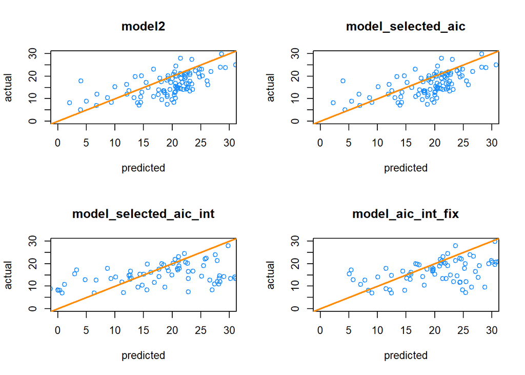

```r
par(mfrow = c(2,2))

plot(predict(model2, bos_tst),bos_tst$cmedv, xlab="predicted",ylab="actual",
     xlim = c( 0, 30), ylim = c(0, 30), col = "dodgerblue", main = "model2")
abline(a=0,b=1, col = "darkorange", lwd = 2)

plot(predict(model_selected_aic, bos_tst),bos_tst$cmedv, xlab="predicted",ylab="actual",
     xlim = c( 0, 30), ylim = c(0, 30), col = "dodgerblue", main = "model_selected_aic")
abline(a=0,b=1, col = "darkorange", lwd = 2)

plot(predict(model_selected_aic_int, bos_tst),bos_tst$cmedv, xlab="predicted",ylab="actual",
     xlim = c( 0, 30), ylim = c(0, 30), col = "dodgerblue", main = "model_selected_aic_int")
abline(a=0,b=1, col = "darkorange", lwd = 2)

plot(predict(model_aic_int_fix, bos_tst),bos_tst$cmedv, xlab="predicted",ylab="actual",
     xlim = c( 0, 30), ylim = c(0, 30), col = "dodgerblue", main = "model_aic_int_fix")
abline(a=0,b=1, col = "darkorange", lwd = 2)
```

```r
#99% Confidence & Prediction Interval of the chosen model

which.max(bos_tst$cmedv)
```

```
## [1] 69
```

```r
exp(predict(model_mix_fix, level = 0.99, interval = "confidence", bos_tst[69,] ))
```

```
##          fit      lwr      upr
## 474 22.01349 20.46585 23.67817
```

```r
exp(predict(model_mix_fix, level = 0.99, interval = "prediction", bos_tst[69,] ))
```

```
##          fit      lwr      upr
## 474 22.01349 16.42219 29.50848
```

[figure not shown]

```r
#plotting the best model for prediction.

plot(exp(predict(model_mix_fix, bos_tst)),bos_tst$cmedv, xlab="predicted",ylab="actual",
     xlim = c( 0, 30), ylim = c(0, 30), col = "dodgerblue", main = "model_pred_trans" )
abline(a=0,b=1, col = "darkorange", lwd = 2)
```

```r
which.min(bos_tst$cmedv)
```

```
## [1] 1
```

```r
bos_tst[1,]
```

```
##     cmedv    crim zn chas   nox    rm age    dis rad tax ptratio      b
## 406     5 67.9208  0    0 0.693 5.683 100 1.4254  24 666    20.2 384.97
##     lstat
## 406 22.98
```

```r
predict(model_pred_trans, bos_tst[1,] )
```

```
##      406
## 1.911767
```

```r
exp(predict(model_res_trans, bos_tst[1,] ))
```

```
##      406
## 6.446122
```

```r
exp(predict(model_res_trans_fix, bos_tst[1,]))
```

```
##      406
## 4.872437
```

```r
exp(predict(model_mix_fix, bos_tst[1,]))
```

```
##      406
## 4.398506
```

**d. discussion**

An important observation during the model selection and diagnostics was the factor variable *town* which I left out from the fitted models for simplicity. So the fitted model esentially takes into acount all significant predictors except the localion factors. However, modern prediction tools do use location/town as one of the major criteria.

The challenges that I faced when selecting **town** was in creating the train and test data sets. I was not able to calculate test RMSE as the test dataset would have new towns which the model wasn’t trained in.

None of the models could predict the actual prices with 100% accuracy, and I think fitting *town* would improve accuracy.

**e. appendix**

Reference for Statistics with R: https://daviddalpiaz.github.io/appliedstats/.

Kaggle data source: https://www.kaggle.com/andyxie/regression-with-r-boston-housing-price.

Actual data source used: http://lib.stat.cmu.edu/datasets/ available with library *mlbench* in R.